# Sangsanae_homework1

Sangsanae Harn-Udomlarp|Assignment1|DSC478 Machine Learning

```python
# Bank data - Pandas
import numpy as np
import pandas as pd
import matplotlib.pyplot as plt
import os
```

```python
# working directory
os.getcwd()
```

```
'/Users/shinesang/Desktop/DSC478 machine learning/Homework1'
```

```python
# Get Working directory
os.chdir('/Users/shinesang/desktop/DSC478 machine learning/Homework1')
```

```python
#Read the bank dataset
df = pd.read_csv('bank_data.csv', index_col = 0)
df.head()
```

| id | age | income | children | gender | region | married | car | savings_acct | current_acct | mortgage | pep |
| --- | --- | --- | --- | --- | --- | --- | --- | --- | --- | --- | --- |
| ID12101 | 48 | 17546.0 | 1 | FEMALE | INNER_CITY | NO | NO | NO | NO | NO | YES |
| ID12102 | 40 | 30085.1 | 3 | MALE | TOWN | YES | YES | NO | YES | YES | NO |
| ID12103 | 51 | 16575.4 | 0 | FEMALE | INNER_CITY | YES | YES | YES | YES | NO | NO |
| ID12104 | 23 | 20375.4 | 3 | FEMALE | TOWN | YES | NO | NO | YES | NO | NO |
| ID12105 | 57 | 50576.3 | 0 | FEMALE | RURAL | YES | NO | YES | NO | NO | NO |

1.Explore (and comment) the general characteristics of the data as a whole: examine the means, standard deviations, and other statistics associated with the numerical attributes; show the distributions of values associated with categorical attributes; etc.

```python
# Get feature types
df.dtypes
```

```
age               int64
income          float64
children          int64
gender           object
region           object
married          object
car              object
savings_acct     object
current_acct     object
mortgage         object
pep              object
dtype: object
```

```python
# Get column names
df.columns
```

```
Index(['age', 'income', 'children', 'gender', 'region', 'married', 'car',
       'savings_acct', 'current_acct', 'mortgage', 'pep'],
      dtype='object')
```

```python
# Get basic statistics
df.describe()
```

|  | age | income | children |
| --- | --- | --- | --- |
| count | 600.000000 | 600.000000 | 600.000000 |
| mean | 42.395000 | 27524.031217 | 1.011667 |
| std | 14.424947 | 12899.468246 | 1.056752 |
| min | 18.000000 | 5014.210000 | 0.000000 |
| 25% | 30.000000 | 17264.500000 | 0.000000 |
| 50% | 42.000000 | 24925.300000 | 1.000000 |
| 75% | 55.250000 | 36172.675000 | 2.000000 |
| max | 67.000000 | 63130.100000 | 3.000000 |

```python
# Explore categorical variable
df.describe(include="all")
```

|  | age | income | children | gender | region | married | car | savings_acct | current_acct | mortgage | pep |
| --- | --- | --- | --- | --- | --- | --- | --- | --- | --- | --- | --- |
| count | 600.000000 | 600.000000 | 600.000000 | 600 | 600 | 600 | 600 | 600 | 600 | 600 | 600 |
| unique | NaN | NaN | NaN | 2 | 4 | 2 | 2 | 2 | 2 | 2 | 2 |
| top | NaN | NaN | NaN | FEMALE | INNER_CITY | YES | NO | YES | YES | NO | NO |
| freq | NaN | NaN | NaN | 300 | 269 | 396 | 304 | 414 | 455 | 391 | 326 |
| mean | 42.395000 | 27524.031217 | 1.011667 | NaN | NaN | NaN | NaN | NaN | NaN | NaN | NaN |
| std | 14.424947 | 12899.468246 | 1.056752 | NaN | NaN | NaN | NaN | NaN | NaN | NaN | NaN |
| min | 18.000000 | 5014.210000 | 0.000000 | NaN | NaN | NaN | NaN | NaN | NaN | NaN | NaN |
| 25% | 30.000000 | 17264.500000 | 0.000000 | NaN | NaN | NaN | NaN | NaN | NaN | NaN | NaN |
| 50% | 42.000000 | 24925.300000 | 1.000000 | NaN | NaN | NaN | NaN | NaN | NaN | NaN | NaN |
| 75% | 55.250000 | 36172.675000 | 2.000000 | NaN | NaN | NaN | NaN | NaN | NaN | NaN | NaN |
| max | 67.000000 | 63130.100000 | 3.000000 | NaN | NaN | NaN | NaN | NaN | NaN | NaN | NaN |

Grouping and aggregating gender variable

```python
# Look at the distribution in gender
df["gender"].value_counts()
```

```
FEMALE    300
MALE      300
Name: gender, dtype: int64
```

```python
# Look at the distribution of numerical variables
df.groupby("gender").mean()
```

| gender | age | income | children |
| --- | --- | --- | --- |
| FEMALE | 43.693333 | 27831.368233 | 1.026667 |
| MALE | 41.096667 | 27216.694200 | 0.996667 |

```python
# the distribution of gender variable
df.groupby(df["gender"]).describe()
```

| gender | age count | age mean | age std | age min | age 25% | age 50% | age 75% | age max | income count | income mean | income ... | income 75% | income max | children count | children mean | children std | children min | children 25% | children 50% | children 75% | children max |
| --- | --- | --- | --- | --- | --- | --- | --- | --- | --- | --- | --- | --- | --- | --- | --- | --- | --- | --- | --- | --- | --- |
| FEMALE | 300.0 | 43.693333 | 14.672545 | 18.0 | 31.0 | 44.0 | 57.0 | 67.0 | 300.0 | 27831.368233 | ... | 34873.10 | 63130.1 | 300.0 | 1.026667 | 1.078502 | 0.0 | 0.0 | 1.0 | 2.0 | 3.0 |
| MALE | 300.0 | 41.096667 | 14.077924 | 18.0 | 29.0 | 40.0 | 52.0 | 67.0 | 300.0 | 27216.694200 | ... | 36610.85 | 59409.1 | 300.0 | 0.996667 | 1.036131 | 0.0 | 0.0 | 1.0 | 2.0 | 3.0 |

2 rows × 24 columns

```python
# Look at married variable
df["married"].value_counts()
```

```
YES    396
NO     204
Name: married, dtype: int64
```

```python
# Look at car variable
df["car"].value_counts()
```

```
NO     304
YES    296
Name: car, dtype: int64
```

```python
# Look at saving acct variable
df["savings_acct"].value_counts()
```

```
YES    414
NO     186
Name: savings_acct, dtype: int64
```

```python
# Look at region variable
df["region"].value_counts()
```

```
INNER_CITY    269
TOWN          173
RURAL          96
SUBURBAN       62
Name: region, dtype: int64
```

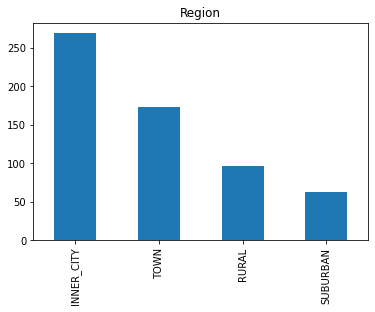

```python
# Make a visualization for each level of region
df["region"].value_counts().plot(kind="bar", title="Region")
```

```python
# Grouping numerical variables of the region variable
df.groupby("region").describe()
```

| region | age count | age mean | age std | age min | age 25% | age 50% | age 75% | age max | income count | income mean | income ... | income 75% | income max | children count | children mean | children std | children min | children 25% | children 50% | children 75% | children max |
| --- | --- | --- | --- | --- | --- | --- | --- | --- | --- | --- | --- | --- | --- | --- | --- | --- | --- | --- | --- | --- | --- |
| INNER_CITY | 269.0 | 41.992565 | 14.987306 | 18.0 | 28.00 | 41.0 | 56.00 | 67.0 | 269.0 | 26843.999963 | ... | 36166.200 | 61554.6 | 269.0 | 0.951673 | 1.019167 | 0.0 | 0.0 | 1.0 | 2.0 | 3.0 |
| RURAL | 96.0 | 43.010417 | 14.396268 | 18.0 | 31.00 | 44.0 | 55.25 | 67.0 | 96.0 | 30027.605417 | ... | 41750.600 | 57398.1 | 96.0 | 1.229167 | 1.156029 | 0.0 | 0.0 | 1.0 | 2.0 | 3.0 |
| SUBURBAN | 62.0 | 43.725806 | 15.222039 | 18.0 | 30.25 | 45.0 | 58.00 | 67.0 | 62.0 | 28656.356935 | ... | 37291.175 | 63130.1 | 62.0 | 0.967742 | 1.039668 | 0.0 | 0.0 | 1.0 | 2.0 | 3.0 |
| TOWN | 173.0 | 42.202312 | 13.299309 | 19.0 | 33.00 | 41.0 | 52.00 | 67.0 | 173.0 | 26786.349653 | ... | 33204.300 | 59803.9 | 173.0 | 1.000000 | 1.056541 | 0.0 | 0.0 | 1.0 | 2.0 | 3.0 |

4 rows × 24 columns

Select which variables to describe

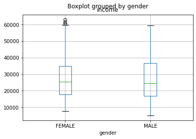

```python
# income and gender
df.boxplot(column='income', by='gender')
```

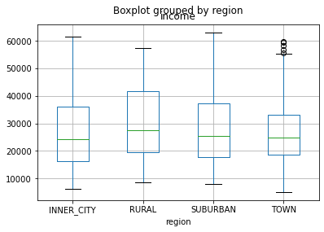

```python
# income and region
df.boxplot(column='income', by='region')
```

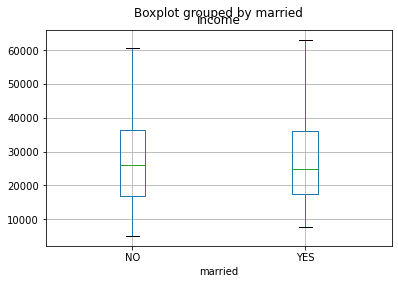

```python
# income and region
df.boxplot(column='income', by='married')
```

2.Suppose that the hypothetical bank is particularly interested in customers who buy the PEP (Personal Equity Plan) product. Compare and contrast the subsets of customers who buy and don't buy the PEP. Compute summaries (as in part 1) of the selected data with respect to all other attributes. Can you observe any significant differences between these segments of customers? Discuss your observations.

From data exploration, the customers who buy the personal equity plan (PEP) have higher incomes. More so, there are higher mean ages in the customers who have the PEP. Comparing to the regeion, peopple who live in the inner city have the most PEP purchase.

```python
# Look at pep variable
df['pep'].value_counts()
```

```
NO     326
YES    274
Name: pep, dtype: int64
```

```python
# Grouping pep variable to look at numerical variables
df.groupby(df['pep']).mean()
```

| pep | age | income | children |
| --- | --- | --- | --- |
| NO | 40.098160 | 24900.953374 | 1.067485 |
| YES | 45.127737 | 30644.919453 | 0.945255 |

```python
# Groupping pep variable to look at all variable
df.groupby(df['pep']).describe()
```

| pep | age count | age mean | age std | age min | age 25% | age 50% | age 75% | age max | income count | income mean | income ... | income 75% | income max | children count | children mean | children std | children min | children 25% | children 50% | children 75% | children max |
| --- | --- | --- | --- | --- | --- | --- | --- | --- | --- | --- | --- | --- | --- | --- | --- | --- | --- | --- | --- | --- | --- |
| NO | 326.0 | 40.098160 | 14.123506 | 18.0 | 27.0 | 40.0 | 51.0 | 67.0 | 326.0 | 24900.953374 | ... | 31210.90 | 61554.6 | 326.0 | 1.067485 | 1.195524 | 0.0 | 0.0 | 0.0 | 2.0 | 3.0 |
| YES | 274.0 | 45.127737 | 14.327991 | 18.0 | 34.0 | 45.0 | 58.0 | 67.0 | 274.0 | 30644.919453 | ... | 38458.35 | 63130.1 | 274.0 | 0.945255 | 0.860571 | 0.0 | 0.0 | 1.0 | 1.0 | 3.0 |

2 rows × 24 columns

```python
# Create pivot table
df1 = pd.crosstab(df["pep"], df["region"])
df1
```

| region pep | INNER_CITY | RURAL | SUBURBAN | TOWN |
| --- | --- | --- | --- | --- |
| NO | 146 | 50 | 28 | 102 |
| YES | 123 | 46 | 34 | 71 |

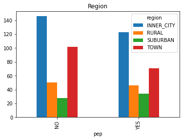

```python
# Create visualization from the pivot table
plt.show(df1.plot(kind="bar", title="Region"))
```

```python
# Look at pep variable by grouping married variable
df2 = pd.crosstab(df["pep"], df["married"])
df2
```

| married pep | NO | YES |
| --- | --- | --- |
| NO | 84 | 242 |
| YES | 120 | 154 |

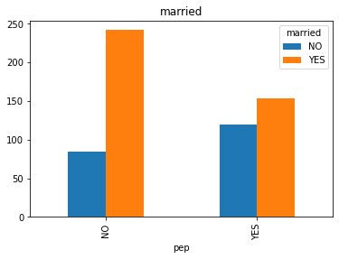

```python
# Create visulization of pep variable with married information
plt.show(df2.plot(kind="bar", title="married"))
```

```python
# Look at pep variable by grouping car variable
df3 = pd.crosstab(df["pep"], df["car"])
df3
```

| car pep | NO | YES |
| --- | --- | --- |
| NO | 168 | 158 |
| YES | 136 | 138 |

[figure not shown]

```python
# Create visulization of pep variable with married information
plt.show(df2.plot(kind="bar", title="car"))
```

From the mortgage, the customers who do not have mortgage buy PEP more than the customers who have mortgage.

```python
# Look at pep variable by grouping car variable
df4 = pd.crosstab(df["pep"], df["mortgage"])
df4
```

| mortgage pep | NO | YES |
| --- | --- | --- |
| NO | 209 | 117 |
| YES | 182 | 92 |

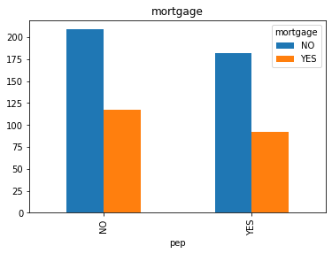

```python
# Create visulization of pep variable with married information
plt.show(df4.plot(kind="bar", title="mortgage"))
```

From the boxplot between pep and income variables, the customers who buy the PEP has a higher income.

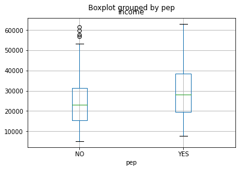

```python
# Create box plot pep variable and income
df5 = df.boxplot(column='income', by='pep')
df5
```

3.Use z-score normalization to standardize the values of the income attribute. [Do not change the original income attribute in the table.]

```python
# Create Z score normalization
income_zscore = (df["income"] - df["income"].mean())/ df["income"].std()
# Show 10 results
income_zscore.head(10)
```

```
id
ID12101   -0.773523
ID12102    0.198541
ID12103   -0.848766
ID12104   -0.554180
ID12105    1.787071
ID12106    0.802015
ID12107   -1.445560
ID12108   -0.199809
ID12109   -0.172079
ID12110   -0.256749
Name: income, dtype: float64
```

```python
# Discretize the age into 3 categories
df_bins = pd.qcut(df.income, 3)
df_bins.head(10)
```

```
id
ID12101     (5014.209, 20253.8]
ID12102    (20253.8, 31132.767]
ID12103     (5014.209, 20253.8]
ID12104    (20253.8, 31132.767]
ID12105    (31132.767, 63130.1]
ID12106    (31132.767, 63130.1]
ID12107     (5014.209, 20253.8]
ID12108    (20253.8, 31132.767]
ID12109    (20253.8, 31132.767]
ID12110    (20253.8, 31132.767]
Name: income, dtype: category
Categories (3, interval[float64]): [(5014.209, 20253.8] < (20253.8, 31132.767] < (31132.767, 63130.1]]
```

```python
# Bin the income variable and print first few
df_bins = pd.qcut(df.income, [0, .33, .66, 1], labels=["young", "mid-age", "old"])
df_bins.head(10)
```

```
id
ID12101      young
ID12102    mid-age
ID12103      young
ID12104    mid-age
ID12105        old
ID12106        old
ID12107      young
ID12108    mid-age
ID12109    mid-age
ID12110    mid-age
Name: income, dtype: category
Categories (3, object): ['young' < 'mid-age' < 'old']
```

5.Use Min-Max Normalization to transform the values of all numeric attributes (income, age, children) in the original table (before the transformations in parts 3 and 4 above) onto the range 0.0-1.0.

```python
# Compute min/max of income - age - chi
min_inc = df["income"].min()
max_inc = df["income"].max()
min_age = df["age"].min()
max_age = df["age"].max()
min_chi = df["children"].min()
max_chi = df["children"].max()
print (min_inc, max_inc, min_age, max_age, min_chi, max_chi)
```

```
5014.21 63130.1 18 67 0 3
```

```python
#min-max normalization
norm_inc = (df["income"] - min_inc) / (max_inc - min_inc)
norm_age = (df["age"] - min_age) / (max_age - min_age)
norm_chi = (df["children"] - min_chi) / (max_chi - min_chi)
print (norm_inc.head(5))
print (norm_age.head(5))
print (norm_chi.head(5))
```

```
id
ID12101    0.215634
ID12102    0.431395
ID12103    0.198933
ID12104    0.264320
ID12105    0.783987
Name: income, dtype: float64
id
ID12101    0.612245
ID12102    0.448980
ID12103    0.673469
ID12104    0.102041
ID12105    0.795918
Name: age, dtype: float64
id
ID12101    0.333333
ID12102    1.000000
ID12103    0.000000
ID12104    1.000000
ID12105    0.000000
Name: children, dtype: float64
```

```python
# Transform to original table

df["norm_inc"] = norm_inc
df["norm_age"] = norm_age
df["norm_chi"] = norm_chi
df["df_bins"] = df_bins
df["income_zscore"] = income_zscore
df.head(15)
```

| id | age | income | children | gender | region | married | car | savings_acct | current_acct | mortgage | pep | norm_inc | norm_age | norm_chi | df_bins | income_zscore |
| --- | --- | --- | --- | --- | --- | --- | --- | --- | --- | --- | --- | --- | --- | --- | --- | --- |
| ID12101 | 48 | 17546.00 | 1 | FEMALE | INNER_CITY | NO | NO | NO | NO | NO | YES | 0.215634 | 0.612245 | 0.333333 | young | -0.773523 |
| ID12102 | 40 | 30085.10 | 3 | MALE | TOWN | YES | YES | NO | YES | YES | NO | 0.431395 | 0.448980 | 1.000000 | mid-age | 0.198541 |
| ID12103 | 51 | 16575.40 | 0 | FEMALE | INNER_CITY | YES | YES | YES | YES | NO | NO | 0.198933 | 0.673469 | 0.000000 | young | -0.848766 |
| ID12104 | 23 | 20375.40 | 3 | FEMALE | TOWN | YES | NO | NO | YES | NO | NO | 0.264320 | 0.102041 | 1.000000 | mid-age | -0.554180 |
| ID12105 | 57 | 50576.30 | 0 | FEMALE | RURAL | YES | NO | YES | NO | NO | NO | 0.783987 | 0.795918 | 0.000000 | old | 1.787071 |
| ID12106 | 57 | 37869.60 | 2 | FEMALE | TOWN | YES | NO | YES | YES | NO | YES | 0.565343 | 0.795918 | 0.666667 | old | 0.802015 |
| ID12107 | 22 | 8877.07 | 0 | MALE | RURAL | NO | NO | NO | YES | NO | YES | 0.066468 | 0.081633 | 0.000000 | young | -1.445560 |
| ID12108 | 58 | 24946.60 | 0 | MALE | TOWN | YES | YES | YES | YES | NO | NO | 0.342977 | 0.816327 | 0.000000 | mid-age | -0.199809 |
| ID12109 | 37 | 25304.30 | 2 | FEMALE | SUBURBAN | YES | YES | NO | NO | NO | NO | 0.349132 | 0.387755 | 0.666667 | mid-age | -0.172079 |
| ID12110 | 54 | 24212.10 | 2 | MALE | TOWN | YES | YES | YES | YES | NO | NO | 0.330338 | 0.734694 | 0.666667 | mid-age | -0.256749 |
| ID12111 | 66 | 59803.90 | 0 | FEMALE | TOWN | YES | NO | YES | YES | NO | NO | 0.942766 | 0.979592 | 0.000000 | old | 2.502419 |
| ID12112 | 52 | 26658.80 | 0 | FEMALE | INNER_CITY | NO | YES | YES | YES | YES | NO | 0.372438 | 0.693878 | 0.000000 | mid-age | -0.067075 |
| ID12113 | 44 | 15735.80 | 1 | FEMALE | TOWN | YES | NO | YES | YES | YES | YES | 0.184486 | 0.530612 | 0.333333 | young | -0.913854 |
| ID12114 | 66 | 55204.70 | 1 | FEMALE | TOWN | YES | YES | YES | YES | YES | YES | 0.863628 | 0.979592 | 0.333333 | old | 2.145877 |
| ID12115 | 36 | 19474.60 | 0 | MALE | RURAL | YES | NO | YES | YES | YES | NO | 0.248820 | 0.367347 | 0.000000 | young | -0.624013 |

6.Combined the normalized numbers from part 5 with dummy variables for the categorical attributes into one table/frame. All attributes should then be numeric and no attribute should be repeated. Save this new data matrix into a file called bank_numeric.csv and submit it along with your assignment. [Hint: you might consider using the get_dummies for Pandas data frames.]

```python
df_dummy = pd.get_dummies(df)
df_dummy.head(10)
```

| id | age | income | children | norm_inc | norm_age | norm_chi | income_zscore | gender_FEMALE | gender_MALE | region_INNER_CITY | ... | savings_acct_YES | current_acct_NO | current_acct_YES | mortgage_NO | mortgage_YES | pep_NO | pep_YES | df_bins_young | df_bins_mid-age | df_bins_old |
| --- | --- | --- | --- | --- | --- | --- | --- | --- | --- | --- | --- | --- | --- | --- | --- | --- | --- | --- | --- | --- | --- |
| ID12101 | 48 | 17546.00 | 1 | 0.215634 | 0.612245 | 0.333333 | -0.773523 | 1 | 0 | 1 | ... | 0 | 1 | 0 | 1 | 0 | 0 | 1 | 1 | 0 | 0 |
| ID12102 | 40 | 30085.10 | 3 | 0.431395 | 0.448980 | 1.000000 | 0.198541 | 0 | 1 | 0 | ... | 0 | 0 | 1 | 0 | 1 | 1 | 0 | 0 | 1 | 0 |
| ID12103 | 51 | 16575.40 | 0 | 0.198933 | 0.673469 | 0.000000 | -0.848766 | 1 | 0 | 1 | ... | 1 | 0 | 1 | 1 | 0 | 1 | 0 | 1 | 0 | 0 |
| ID12104 | 23 | 20375.40 | 3 | 0.264320 | 0.102041 | 1.000000 | -0.554180 | 1 | 0 | 0 | ... | 0 | 0 | 1 | 1 | 0 | 1 | 0 | 0 | 1 | 0 |
| ID12105 | 57 | 50576.30 | 0 | 0.783987 | 0.795918 | 0.000000 | 1.787071 | 1 | 0 | 0 | ... | 1 | 1 | 0 | 1 | 0 | 1 | 0 | 0 | 0 | 1 |
| ID12106 | 57 | 37869.60 | 2 | 0.565343 | 0.795918 | 0.666667 | 0.802015 | 1 | 0 | 0 | ... | 1 | 0 | 1 | 1 | 0 | 0 | 1 | 0 | 0 | 1 |
| ID12107 | 22 | 8877.07 | 0 | 0.066468 | 0.081633 | 0.000000 | -1.445560 | 0 | 1 | 0 | ... | 0 | 0 | 1 | 1 | 0 | 0 | 1 | 1 | 0 | 0 |
| ID12108 | 58 | 24946.60 | 0 | 0.342977 | 0.816327 | 0.000000 | -0.199809 | 0 | 1 | 0 | ... | 1 | 0 | 1 | 1 | 0 | 1 | 0 | 0 | 1 | 0 |
| ID12109 | 37 | 25304.30 | 2 | 0.349132 | 0.387755 | 0.666667 | -0.172079 | 1 | 0 | 0 | ... | 0 | 1 | 0 | 1 | 0 | 1 | 0 | 0 | 1 | 0 |
| ID12110 | 54 | 24212.10 | 2 | 0.330338 | 0.734694 | 0.666667 | -0.256749 | 0 | 1 | 0 | ... | 1 | 0 | 1 | 1 | 0 | 1 | 0 | 0 | 1 | 0 |

10 rows × 28 columns

```python
#Write dummy dataset to a file - "bank_numeric.csv"
df_dummy.to_csv('bank_numeric.csv')
```

7.Using the standardized data set (of the previous part), perform basic correlation analysis among the attributes. Discuss your results by indicating any significant positive or negative correlations among pairs of attributes. You need to construct a complete Correlation Matrix. Be sure to first remove the Customer ID column before creating the correlation matrix. [Hint: you can create the correlation matrix by using the corr() function in Pandas, try at least two corr methods and compare them].

```python
corr = df_dummy.corr()
corr
```

|  | age | income | children | norm_inc | norm_age | norm_chi | income_zscore | gender_FEMALE | gender_MALE | region_INNER_CITY | ... | savings_acct_YES | current_acct_NO | current_acct_YES | mortgage_NO | mortgage_YES | pep_NO | pep_YES | df_bins_young | df_bins_mid-age | df_bins_old |
| --- | --- | --- | --- | --- | --- | --- | --- | --- | --- | --- | --- | --- | --- | --- | --- | --- | --- | --- | --- | --- | --- |
| age | 1.000000 | 0.752726 | 0.023572 | 0.752726 | 1.000000 | 0.023572 | 0.752726 | 0.090081 | -0.090081 | -0.025171 | ... | 0.184389 | 0.035312 | -0.035312 | 0.016154 | -0.016154 | -0.173825 | 0.173825 | -0.625438 | 0.026508 | 0.594510 |
| income | 0.752726 | 1.000000 | 0.036761 | 1.000000 | 0.752726 | 0.036761 | 1.000000 | 0.023845 | -0.023845 | -0.047564 | ... | 0.266164 | -0.031616 | 0.031616 | 0.014662 | -0.014662 | -0.221991 | 0.221991 | -0.713169 | -0.130834 | 0.837775 |
| children | 0.023572 | 0.036761 | 1.000000 | 0.036761 | 0.023572 | 1.000000 | 0.036761 | 0.014206 | -0.014206 | -0.051222 | ... | 0.041536 | -0.006238 | 0.006238 | 0.074339 | -0.074339 | 0.057663 | -0.057663 | -0.004398 | -0.068179 | 0.072041 |
| norm_inc | 0.752726 | 1.000000 | 0.036761 | 1.000000 | 0.752726 | 0.036761 | 1.000000 | 0.023845 | -0.023845 | -0.047564 | ... | 0.266164 | -0.031616 | 0.031616 | 0.014662 | -0.014662 | -0.221991 | 0.221991 | -0.713169 | -0.130834 | 0.837775 |
| norm_age | 1.000000 | 0.752726 | 0.023572 | 0.752726 | 1.000000 | 0.023572 | 0.752726 | 0.090081 | -0.090081 | -0.025171 | ... | 0.184389 | 0.035312 | -0.035312 | 0.016154 | -0.016154 | -0.173825 | 0.173825 | -0.625438 | 0.026508 | 0.594510 |
| norm_chi | 0.023572 | 0.036761 | 1.000000 | 0.036761 | 0.023572 | 1.000000 | 0.036761 | 0.014206 | -0.014206 | -0.051222 | ... | 0.041536 | -0.006238 | 0.006238 | 0.074339 | -0.074339 | 0.057663 | -0.057663 | -0.004398 | -0.068179 | 0.072041 |
| income_zscore | 0.752726 | 1.000000 | 0.036761 | 1.000000 | 0.752726 | 0.036761 | 1.000000 | 0.023845 | -0.023845 | -0.047564 | ... | 0.266164 | -0.031616 | 0.031616 | 0.014662 | -0.014662 | -0.221991 | 0.221991 | -0.713169 | -0.130834 | 0.837775 |
| gender_FEMALE | 0.090081 | 0.023845 | 0.014206 | 0.023845 | 0.090081 | 0.014206 | 0.023845 | 1.000000 | -1.000000 | -0.023459 | ... | -0.007207 | -0.019466 | 0.019466 | 0.066465 | -0.066465 | 0.046843 | -0.046843 | -0.014178 | 0.028356 | -0.014073 |
| gender_MALE | -0.090081 | -0.023845 | -0.014206 | -0.023845 | -0.090081 | -0.014206 | -0.023845 | -1.000000 | 1.000000 | 0.023459 | ... | 0.007207 | 0.019466 | -0.019466 | -0.066465 | 0.066465 | -0.046843 | 0.046843 | 0.014178 | -0.028356 | 0.014073 |
| region_INNER_CITY | -0.025171 | -0.047564 | -0.051222 | -0.047564 | -0.025171 | -0.051222 | -0.047564 | -0.023459 | 0.023459 | 1.000000 | ... | -0.091373 | -0.007894 | 0.007894 | -0.002098 | 0.002098 | -0.001054 | 0.001054 | 0.108546 | -0.098141 | -0.010329 |
| region_RURAL | 0.018635 | 0.084776 | 0.089902 | 0.084776 | 0.018635 | 0.089902 | 0.084776 | -0.009092 | 0.009092 | -0.393444 | ... | 0.036960 | 0.008496 | -0.008496 | 0.051908 | -0.051908 | -0.019714 | 0.019714 | -0.054917 | -0.016243 | 0.070634 |
| region_SUBURBAN | 0.031345 | 0.029824 | -0.014122 | 0.029824 | 0.031345 | -0.014122 | 0.029824 | -0.010951 | 0.010951 | -0.306032 | ... | 0.002605 | -0.038157 | 0.038157 | -0.004635 | 0.004635 | -0.062508 | 0.062508 | -0.017001 | 0.017932 | -0.000925 |
| region_TOWN | -0.008510 | -0.036431 | -0.007033 | -0.036431 | -0.008510 | -0.007033 | -0.036431 | 0.040472 | -0.040472 | -0.573814 | ... | 0.068654 | 0.027431 | -0.027431 | -0.036591 | 0.036591 | 0.059115 | -0.059115 | -0.063302 | 0.108842 | -0.045204 |
| married_NO | -0.010394 | 0.008386 | 0.048716 | 0.008386 | -0.010394 | 0.048716 | 0.008386 | 0.021110 | -0.021110 | -0.003254 | ... | -0.028604 | -0.059996 | 0.059996 | -0.021711 | 0.021711 | -0.189578 | 0.189578 | -0.009877 | -0.009877 | 0.019608 |
| married_YES | 0.010394 | -0.008386 | -0.048716 | -0.008386 | 0.010394 | -0.048716 | -0.008386 | -0.021110 | 0.021110 | 0.003254 | ... | 0.028604 | 0.059996 | -0.059996 | 0.021711 | -0.021711 | 0.189578 | -0.189578 | 0.009877 | 0.009877 | -0.019608 |
| car_NO | -0.077733 | -0.081556 | -0.036455 | -0.081556 | -0.077733 | -0.036455 | -0.081556 | 0.006667 | -0.006667 | 0.018143 | ... | -0.034310 | -0.034783 | 0.034783 | -0.007743 | 0.007743 | 0.018917 | -0.018917 | 0.075717 | 0.011911 | -0.086981 |
| car_YES | 0.077733 | 0.081556 | 0.036455 | 0.081556 | 0.077733 | 0.036455 | 0.081556 | -0.006667 | 0.006667 | -0.018143 | ... | 0.034310 | 0.034783 | -0.034783 | 0.007743 | -0.007743 | -0.018917 | 0.018917 | -0.075717 | -0.011911 | 0.086981 |
| savings_acct_NO | -0.184389 | -0.266164 | -0.041536 | -0.266164 | -0.184389 | -0.041536 | -0.266164 | 0.007207 | -0.007207 | 0.091373 | ... | -1.000000 | 0.042511 | -0.042511 | -0.001588 | 0.001588 | -0.072779 | 0.072779 | 0.104382 | 0.142702 | -0.245260 |
| savings_acct_YES | 0.184389 | 0.266164 | 0.041536 | 0.266164 | 0.184389 | 0.041536 | 0.266164 | -0.007207 | 0.007207 | -0.091373 | ... | 1.000000 | -0.042511 | 0.042511 | 0.001588 | -0.001588 | 0.072779 | -0.072779 | -0.104382 | -0.142702 | 0.245260 |
| current_acct_NO | 0.035312 | -0.031616 | -0.006238 | -0.031616 | 0.035312 | -0.006238 | -0.031616 | -0.019466 | 0.019466 | -0.007894 | ... | -0.042511 | 1.000000 | -1.000000 | -0.036704 | 0.036704 | 0.025141 | -0.025141 | -0.023597 | 0.067480 | -0.043559 |
| current_acct_YES | -0.035312 | 0.031616 | 0.006238 | 0.031616 | -0.035312 | 0.006238 | 0.031616 | 0.019466 | -0.019466 | 0.007894 | ... | 0.042511 | -1.000000 | 1.000000 | 0.036704 | -0.036704 | -0.025141 | 0.025141 | 0.023597 | -0.067480 | 0.043559 |
| mortgage_NO | 0.016154 | 0.014662 | 0.074339 | 0.014662 | 0.016154 | 0.074339 | 0.014662 | 0.066465 | -0.066465 | -0.002098 | ... | 0.001588 | -0.036704 | 0.036704 | 1.000000 | -1.000000 | -0.024182 | 0.024182 | 0.007216 | -0.022542 | 0.015212 |
| mortgage_YES | -0.016154 | -0.014662 | -0.074339 | -0.014662 | -0.016154 | -0.074339 | -0.014662 | -0.066465 | 0.066465 | 0.002098 | ... | -0.001588 | 0.036704 | -0.036704 | -1.000000 | 1.000000 | 0.024182 | -0.024182 | -0.007216 | 0.022542 | -0.015212 |
| pep_NO | -0.173825 | -0.221991 | 0.057663 | -0.221991 | -0.173825 | 0.057663 | -0.221991 | 0.046843 | -0.046843 | -0.001054 | ... | 0.072779 | 0.025141 | -0.025141 | -0.024182 | 0.024182 | 1.000000 | -1.000000 | 0.152420 | 0.045683 | -0.196641 |
| pep_YES | 0.173825 | 0.221991 | -0.057663 | 0.221991 | 0.173825 | -0.057663 | 0.221991 | -0.046843 | 0.046843 | 0.001054 | ... | -0.072779 | -0.025141 | 0.025141 | 0.024182 | -0.024182 | -1.000000 | 1.000000 | -0.152420 | -0.045683 | 0.196641 |
| df_bins_young | -0.625438 | -0.713169 | -0.004398 | -0.713169 | -0.625438 | -0.004398 | -0.713169 | -0.014178 | 0.014178 | 0.108546 | ... | -0.104382 | -0.023597 | 0.023597 | 0.007216 | -0.007216 | 0.152420 | -0.152420 | 1.000000 | -0.492537 | -0.503718 |
| df_bins_mid-age | 0.026508 | -0.130834 | -0.068179 | -0.130834 | 0.026508 | -0.068179 | -0.130834 | 0.028356 | -0.028356 | -0.098141 | ... | -0.142702 | 0.067480 | -0.067480 | -0.022542 | 0.022542 | 0.045683 | -0.045683 | -0.492537 | 1.000000 | -0.503718 |
| df_bins_old | 0.594510 | 0.837775 | 0.072041 | 0.837775 | 0.594510 | 0.072041 | 0.837775 | -0.014073 | 0.014073 | -0.010329 | ... | 0.245260 | -0.043559 | 0.043559 | 0.015212 | -0.015212 | -0.196641 | 0.196641 | -0.503718 | -0.503718 | 1.000000 |

28 rows × 28 columns

8.Using Matplotlib library and/or ploting capabilties of Pandas, create a scatter plot of the (non-normalized) Income attribute relative to Age. Be sure that your plot contains appropriate labels for the axes. Do these variables seem correlated?

From Q7, there is a strong correlation between age and income.

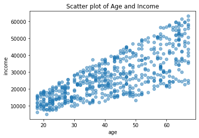

```python
# Create scatter plot
plt.scatter(df["age"], df["income"], alpha = .5)
plt.xlabel("age")
plt.ylabel("income")
plt.title("Scatter plot of Age and Income")
plt.show()
```

9.Create histograms for (non-normalized) Income (using 10 bins) and Age (using 14 bins).

```
<function matplotlib.pyplot.show(close=None, block=None)>
```

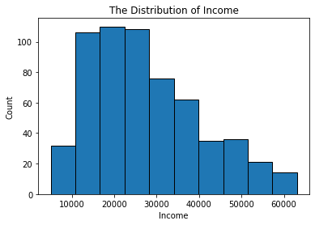

```python
# Creat histograms for income (non - normalized data)
plt.hist(x = df["income"], bins = 10, edgecolor='black')
plt.xlabel("Income")
plt.ylabel("Count")
plt.title("The Distribution of Income")
plt.show
```

```
<function matplotlib.pyplot.show(close=None, block=None)>
```

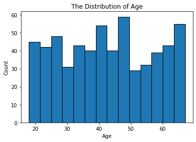

```python
# Creat histograms for age (non - normalized data)
plt.hist(x = df["age"], bins = 14, edgecolor='black')
plt.xlabel("Age")
plt.ylabel("Count")
plt.title("The Distribution of Age")
plt.show
```

10.Using a bargraph, plot the distribution of the values of the region attribute.

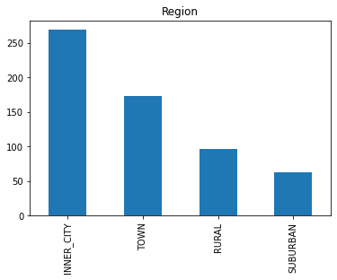

```python
# Make a visualization for each level of region
df["region"].value_counts().plot(kind="bar", title="Region",)
```

11.Perform a cross-tabulation of the region attribute with the pep attribute. This requires the aggregation of the occurrences of each pep value (yes or no) separately for each value of the region attribute. Show the results as a 4 by 2 (region x pep) table with entries representing the counts. [Hint: you can either use Numpy or use aggregations fucntions in Pandas such as groupby() and cross-tab().] Then, either using Matplotlib directly or the plot() function in Pandas create a bar chart graph to visualize of the relationships between these sets of variables. [Hint: This example of creating simple bar charts using Matplotlib may be useful.]

```python
#Create pivot table
df1 = pd.crosstab(df["pep"], df["region"])
df1
```

| region pep | INNER_CITY | RURAL | SUBURBAN | TOWN |
| --- | --- | --- | --- | --- |
| NO | 146 | 50 | 28 | 102 |
| YES | 123 | 46 | 34 | 71 |

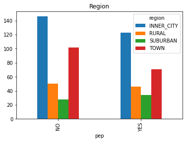

```python
# Create visualization from the pivot table
plt.show(df1.plot(kind="bar", title="Region"))
```